# Motivated Responding on Wason Selection Task

As you might recall, I included a Wason Selection task in my subject pool experiment. Here is a brief report of the data that I wrote on the plane after SPSP.

### Experimental Conditions

Here are the two conditions I used in the subject pool study.

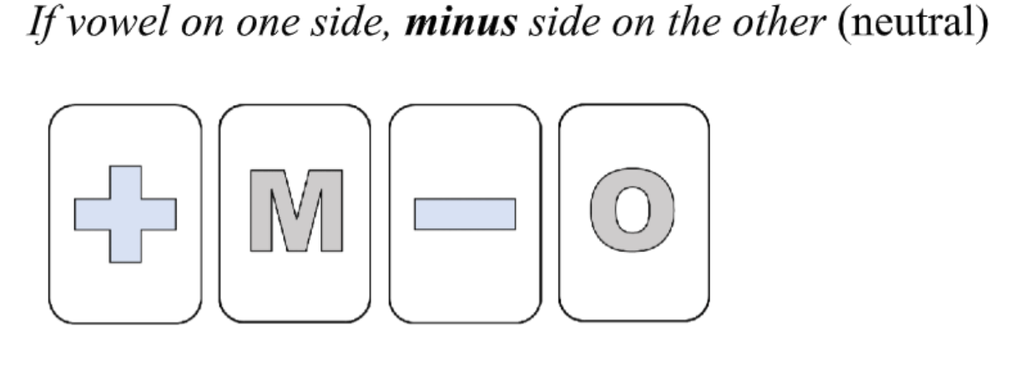

[figure not shown]

I anticipated that in the logo condition, participants would be less likely to arrive at the correct answer (osu logo and plus sign) because it would require pairing an outgroup object with a positively valenced symbol.

### Accurate Response

First I looked at which condition yielded more accurate responses. This was coded 1 if they responded with (plus, o/osu logo) and 0 otherwise.

|  | correct | incorrect |
| --- | --- | --- |
| control | 4 | 76 |
| logo | 12 | 72 |

Among control Ss, 5% responded with the correct answer, compared to 14.3% of those in the experimental condition.

Including experimental condition yielded a significant improvement in the model over an intercepts-only model, $\Delta\chi$<sup>2</sup>(1) = 4.2, *p* = 0.041. Experimental condition was trending as a predictor, such that Ss in the experimental condition were *more likely* to arrive at the correct answer, *b* = 1.15, *p* = .055. The odds ratio suggests that a student being in the experimental condition being correct is 3.17 times greater than a student in the control condition, 95% CI[1.05 11.74].

### Intuitive Response

What about modeling the task as whether or not a student selected the intuitive response? Here, the DV is coded 1 if they responded (negative, o/osu logo) and 0 if they responded otherwise.

|  | intuitive response | other |
| --- | --- | --- |
| control | 37 | 43 |
| logo | 26 | 58 |

Among control Ss, 46.2% responded with the intuitive answer, compared to 31% of those in the experimental condition.

Again, including experimental condition produced a significant improvement in the model over an intercepts-only model, $\Delta\chi$<sup>2</sup>(1) = 4.07, p = 0.044. Experimental condition significantly predicted intuitive responding, such that Ss in the experimental condition were *less likely* to report an intuitive response, *b* = -0.65, *p* = .045. The odds ratio suggests that Ss in the experimental condition giving an intuitive response is 0.52 times greater than Ss in the control condition, 95% CI[0.27 0.98].

### Conclusion

This was the opposite of what I predicted. My only suspicion is that activating ingroup/outgroup is generally increasing cognitive processing, but not in any particular direction.

I am probably going to follow-up with this with the subject pool this semester. The plus/minus stimuli is incredibly subtle, so I’ll try with a more obvious positive/negative valenced attitude object.